# CFRM 502, Winter 2020

# Instructor: Bahman Angoshtari

# Solution to Homework 4

**Grading policy:** This homework has **40** points. Q1 and Q2 are not graded. Q3 has 7 points, Q4 has 15points, and Q5 has 10points. The remaining 8 points are awarded for "sufficient effort" shown in solving Q1 and Q2.

$\newcommand\Fc{\mathscr{F}}$ $\newcommand{\eps}{\varepsilon}$ $\newcommand{\Var}{\operatorname{Var}}$ $\newcommand\Cov{\operatorname{Cov}}$ $\newcommand\Corr{\operatorname{Corr}}$ $\newcommand{\sig}{\sigma}$ $\newcommand\Sig{\Sigma}$ $\newcommand{\al}{\alpha}$ $\newcommand{\gam}{\gamma}$ $\newcommand\Gam{\Gamma}$ $\newcommand\lam{\lambda}$ $\newcommand{\Del}{\Delta}$ $\newcommand\tht{\theta}$ $\newcommand\ph{\varphi}$ $\newcommand\om{\omega}$ $\newcommand\Om{\Omega}$ $\newcommand\rb{\bar{r}}$ $\newcommand{\Xb}{\bar{X}}$ $\newcommand{\Yb}{\bar{Y}}$ $\newcommand\Eb{\mathbb{E}}$ $\newcommand\Pb{\mathbb{P}}$ $\newcommand\Qb{\mathbb{Q}}$ $\newcommand\Rb{\mathbb{R}}$ $\newcommand\Zb{\mathbb{Z}}$ $\newcommand\Nb{\mathbb{N}}$ $\newcommand\Av{\textbf{A}}$ $\newcommand\Ev{\textbf{E}}$ $\newcommand\Dv{\textbf{D}}$ $\newcommand\Fv{\textbf{F}}$ $\newcommand\Gv{\textbf{G}}$ $\newcommand\Hv{\textbf{H}}$ $\newcommand\Kv{\textbf{K}}$ $\newcommand\Iv{\textbf{I}}$ $\newcommand\Pv{\textbf{P}}$ $\newcommand\Ov{\textbf{O}}$ $\newcommand\Sv{\textbf{S}}$ $\newcommand\Xv{\textbf{X}}$ $\newcommand\Yv{\textbf{Y}}$ $\newcommand\Zv{\textbf{Z}}$ $\newcommand\av{\mathbf{a}}$ $\newcommand\xv{\mathbf{x}}$ $\newcommand\yv{\mathbf{y}}$ $\newcommand\zv{\mathbf{z}}$ $\newcommand\Cv{\mathbf{C}}$ $\newcommand\mv{\mathbf{m}}$ $\newcommand\nv{\mathbf{n}}$ $\newcommand\pv{\mathbf{p}}$ $\newcommand\sv{\mathbf{s}}$ $\newcommand\wv{\mathbf{w}}$ $\newcommand\Wv{\textbf{W}}$ $\newcommand\alv{{\boldsymbol\al}}$ $\newcommand\betav{{\boldsymbol\beta}}$ $\newcommand\etav{{\boldsymbol\eta}}$ $\newcommand\epsv{{\boldsymbol\varepsilon}}$ $\newcommand\delv{{\boldsymbol\delta}}$ $\newcommand\Lamv{{\boldsymbol\Lambda}}$ $\newcommand\lamv{{\boldsymbol\lambda}}$ $\newcommand\muv{{\boldsymbol\mu}}$ $\newcommand\piv{{\boldsymbol\pi}}$ $\newcommand\Piv{{\boldsymbol\Pi}}$ $\newcommand\Gamv{{\boldsymbol\Gam}}$ $\newcommand\Phiv{{\boldsymbol\Phi}}$ $\newcommand\Sigv{{\boldsymbol\Sig}}$ $\newcommand\ah{\widehat{a}}$ $\newcommand\Pbh{\widehat{\Pb}}$ $\newcommand\phh{\widehat{\varphi}}$ $\newcommand\Ebh{\widehat{\Eb}}$ $\newcommand\Qh{\widehat{Q}}$ $\newcommand\Ih{\widehat{I}}$ $\newcommand\rh{\widehat{r}}$ $\newcommand\pih{\widehat{\pi}}$ $\newcommand\Pih{\widehat{\Pi}}$ $\newcommand\Sigvh{\widehat{\Sigv}}$ $\newcommand\Wh{\widehat{W}}$ $\newcommand\Fh{\widehat{F}}$ $\newcommand\Yh{\widehat{Y}}$ $\newcommand\Zh{\widehat{Z}}$ $\newcommand\Yvh{\widehat{\Yv}}$ $\newcommand\Ah{\widehat{\Ac}}$ $\newcommand\uh{\widehat{u}}$ $\newcommand\vh{\widehat{v}}$ $\newcommand\fh{\widehat{f}}$ $\newcommand\hh{\widehat{h}}$ $\newcommand\Bh{\widehat{B}}$ $\newcommand\Ovh{\widehat{\Ov}}$ $\newcommand\Xvh{\widehat{\Xv}}$ $\newcommand\rhoh{\widehat{\rho}}$ $\newcommand\nuh{\widehat{\nu}}$ $\newcommand\varphih{\widehat{\varphi}}$ $\newcommand\alh{\widehat{\al}}$ $\newcommand\thetah{\widehat{\theta}}$ $\newcommand\betah{\widehat{\beta}}$ $\newcommand\betavh{\widehat{\boldsymbol\beta}}$ $\newcommand\kaph{\widehat{\kappa}}$ $\newcommand\sigh{\widehat{\sigma}}$ $\newcommand\epsh{\widehat{\eps}}$ $\newcommand\epsvh{\widehat{\epsv}}$ $\newcommand\epst{\widetilde{\eps}}$ $\newcommand\muh{\widehat{\mu}}$ $\newcommand\dd{\mathrm{d}}$ $\newcommand\ee{\mathrm{e}}$ $\newcommand{\var}[1]{\text{Var} \left( #1 \right)}$

The following code sets up graphics in the Juypter notebook.

```r
# Setting parameters of the Jupyter notebook
sc = .75
options(repr.plot.width=16*sc,
        repr.plot.height=7*sc,
        repr.plot.pointsize = 13, # Text height in pt
        repr.plot.bg        = 'white',
        repr.plot.antialias = 'gray',
        #nice medium-res DPI
        repr.plot.res       = 300,
        #jpeg quality bumped from default
        repr.plot.quality   = 90,
        #vector font family
        repr.plot.family    = 'serif') # Vector font family. 'sans', 'serif', 'mono' or a specific one
```

# 1

**(0 points)** Consider the daily VIX index of the Chicago Board Options Exchange (CBOE) from January 2, 1990 to March 31, 2015. You may obtain this data (and remove missing values) by running the following R code.

```r
library("quantmod")
getSymbols("VIXCLS", src="FRED")
VIX = na.omit(VIXCLS["1990-01/2015-03"])
```

[output not shown]

'VIXCLS'

Alternatively, you may load that data from the text file `HW4-Q1.txt` that is posted with this homework, using

```r
library(xts)
dat=read.table("HW4-Q1.txt", header=TRUE, sep = ",")
VIX=xts(dat[,-1], order.by=as.Date(dat[, 1]))
names(VIX) = c("VIXCLS")
```

The resulting variable "VIX" should have 6359 observations. Let $v_t = \log(\text{VIX}_t)$.

## (a)

Instead of using a proper time series model, we decide to use a simple line regression model

\begin{align*} v_t = \beta_0 + \beta_1 v_{t-1} + \eps_t \end{align*}

Fit this model (i.e. express the estimated values $\betah_0$ and $\betah_1$). Provide a scatter plot of $v_t$ versus its lagged value $v_{t-1}$ and include the fitted line.

**Solution:**

The fitted model is $v_t = 0.046698 + 0.984040 v_{t-1} + \eps_t$, where both coefficients are highly significant. Note that the R-squred is 96\%.

```
Call:
lm(formula = Y ~ X)

Residuals:
     Min       1Q   Median       3Q      Max
-0.33804 -0.03615 -0.00329  0.03124  0.48780

Coefficients:
            Estimate Std. Error t value Pr(>|t|)
(Intercept) 0.046698   0.006583   7.093 1.45e-12 ***
X           0.984040   0.002234 440.569  < 2e-16 ***
---
Signif. codes:  0 ‘***’ 0.001 ‘**’ 0.01 ‘*’ 0.05 ‘.’ 0.1 ‘ ’ 1

Residual standard error: 0.06158 on 6356 degrees of freedom
Multiple R-squared:  0.9683,	Adjusted R-squared:  0.9683
F-statistic: 1.941e+05 on 1 and 6356 DF,  p-value: < 2.2e-16
```

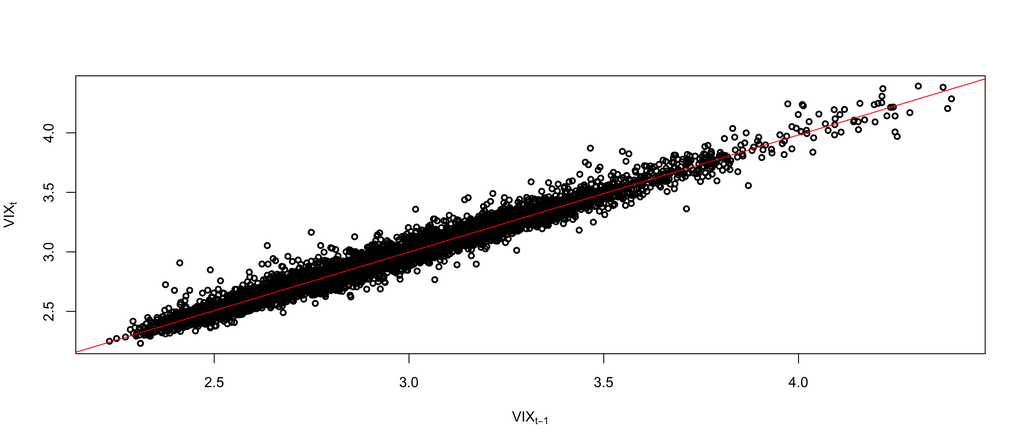

```r
v = log(VIX)
n = dim(v)[1]
Y = coredata(v)[-1]
X = coredata(v)[-n]
Fit = lm(Y~X)
summary(Fit)
par(mfrow=c(1,1))
plot(X,Y,lwd=2,xlab=expression(VIX[t-1]), ylab=expression(VIX[t]),cex=.75)
abline(Fit, col=2)
```

## (b)

Do a full regression diagnostic on the fitted model in part (a).

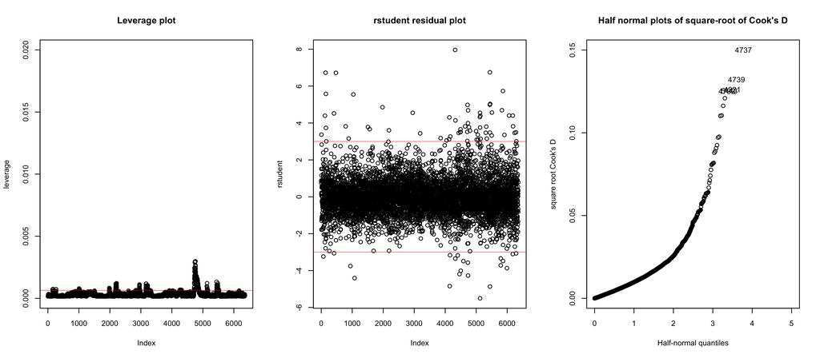

```r
par(mfrow=c(1,3))
plot(hatvalues(Fit), ylab="leverage",main="Leverage plot", ylim=c(0,0.02))
p=1;
abline(h=2*((p+1)/n),lwd=0.5,col=2)
min_rstudent = min(rstudent(Fit))
max_rstudent = max(rstudent(Fit))
plot(rstudent(Fit), ylim = c(min(-5, min_rstudent), max(5, max_rstudent)),
     ylab="rstudent",main="rstudent residual plot")
abline(h=c(-3, 3),lwd=0.5,col=2)
library(faraway) # needed for half normal plots
halfnorm(sqrt(cooks.distance(Fit)), xlim=c(0,5), nlab = 5,
         ylab=("square root Cook's D"),
         main="Half normal plots of square-root of Cook's D")
```

The plot of absolute rstudent shows higher variance for larger fitted values.

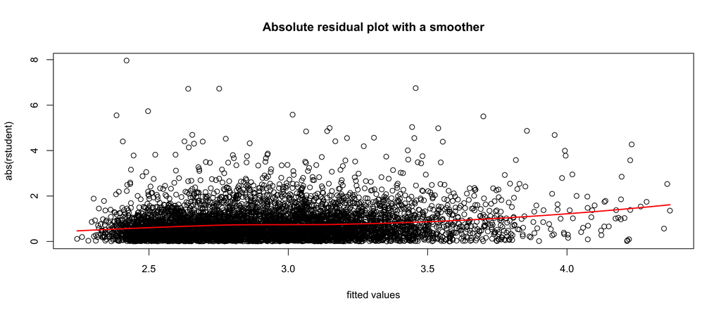

```r
plot(fitted(Fit), abs(rstudent(Fit)),
     xlab = "fitted values", ylab = "abs(rstudent)",
     main = "Absolute residual plot with a smoother")
smoother = loess(abs(rstudent(Fit)) ~ fitted(Fit))
ord = order(fitted(Fit)) # why do we need this line?
lines(fitted(Fit)[ord], fitted(smoother)[ord], col="red", lwd=2)
```

The sample ACF of the residuals and the Ljung-Box test both indicate autocorrelation in the residual.

```
	Box-Ljung test

data:  rstudent(Fit)
X-squared = 81.152, df = 4, p-value < 2.2e-16
```

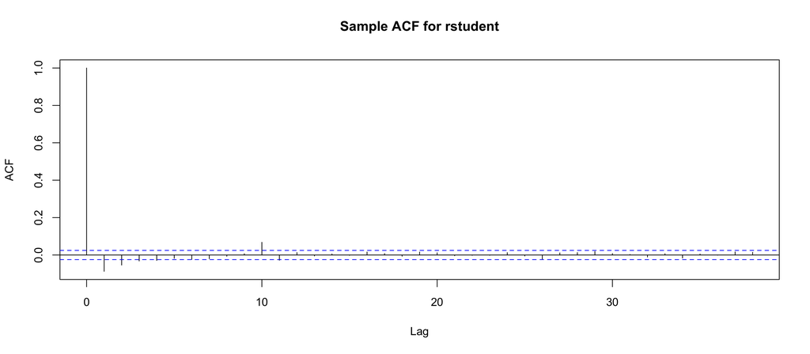

```r
acf(rstudent(Fit), main="Sample ACF for rstudent")
Box.test(rstudent(Fit), lag = 5, type = "Ljung-Box", fitdf = 1) # Note that you should specify fitdf
```

The plot of rstudent vs. VIX$_{t-1}$ shows no identifiable trend. So, the model seems to be linear.

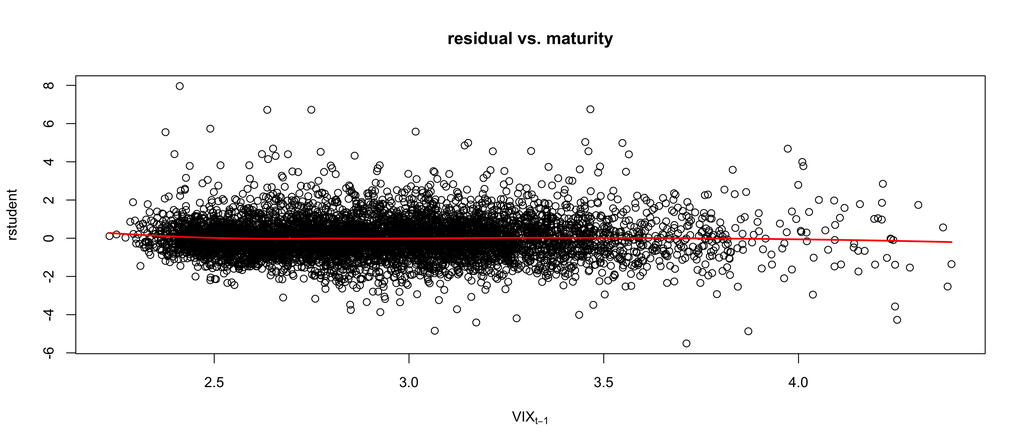

```r
par(mfrow=c(1,1))
plot(X, rstudent(Fit),
     xlab = expression(VIX[t-1]), ylab = "rstudent",
     main = "residual vs. maturity")
smoother = loess(rstudent(Fit) ~ X)
ord = order(X)
lines(X[ord], fitted(smoother)[ord], col="red", lwd=2)
```

The normal probability plot shows heavy tails, but this is expected from financial data.

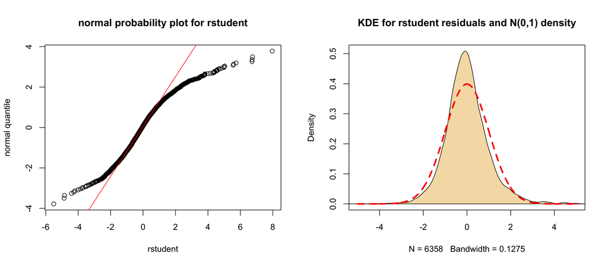

```r
par(mfrow=c(1,2))
qqnorm(rstudent(Fit), datax = TRUE,
       xlab = "normal quantile", # this is for the theoretical quantiles
       ylab = "rstudent", # this is for the sample quantiles
       main = "normal probability plot for rstudent")
qqline(rstudent(Fit), datax=TRUE, col = 2)
d <- density(rstudent(Fit), adjust = 1, na.rm = TRUE)
plot(d, type = "n", xlim=c(-5,5), main="KDE for rstudent residuals and N(0,1) density") # more sophisticated plot
polygon(d, col = "wheat")
z = seq(from=-5,to=5,by=.01)
lines(z,dnorm(z), lty=2,lwd=3,col="red")
```

## (c)

Is the model in part (a) appropriate for modeling the VIX time series? In other words, can it be used for forecasting future VIX values? Explain your answer.

**Solution:**

This model is not statistically reliable, nor is it of practical use.

The most important **red flag** is that the residual are autocorrelated. This means that the regression model is **spurious regression**. Also, as the analysis of part (b) showed, there may be many residuals outliers in the sample due to heavy tails and/or non-constant variance of the errors.

Even if we accept the estimated model in (a), it is of no practical use. The model essentially mentions that the next day log-price is 98.4\% of today's log-price plus error. There is little information about the next day return (i.e. price change) in this statement, as the return is the error in the model.

# 2

## (a)

Does VIX have zero growth rate? That is, test for $H_0: \Eb(z_t)=0$. Draw your conclusion.

```r
z = diff(v)[-1]
n = dim(z)[1]
t = sqrt(n)*mean(z)/sd(z)
2*(1- pnorm(abs(t))) #p-value of the test
```

0.980573717370077

```r
t.test(coredata(z))
```

```
	One Sample t-test

data:  coredata(z)
t = -0.02435, df = 6357, p-value = 0.9806
alternative hypothesis: true mean is not equal to 0
95 percent confidence interval:
 -0.001538794  0.001501036
sample estimates:
    mean of x
-1.887909e-05
```

## (b)

Is $\{z_t\}$ autocorrelated? Support your answer with appropriate tests.

**Solution:**

The TS is autocorrelated. The sample ACF plot shows significant autocorrelation for the first 4 lags. The Ljung-Box test for 5 and 10 lags are also highly significant, rejecting the null hypothesis of zero correlation.

```
	Box-Ljung test

data:  z
X-squared = 106.65, df = 5, p-value < 2.2e-16
```

```
	Box-Ljung test

data:  z
X-squared = 142.95, df = 10, p-value < 2.2e-16
```

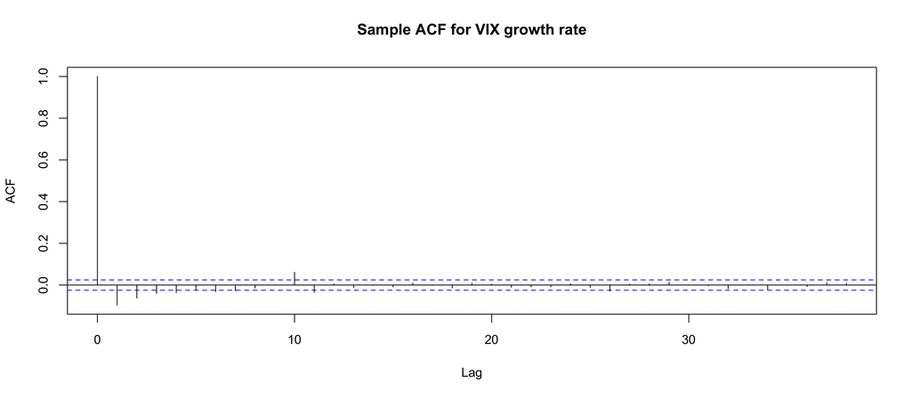

```r
acf(z, main="Sample ACF for VIX growth rate")
Box.test(z, lag = 5, type = "Ljung-Box") # Ljung-Box Q(5)
Box.test(z, lag = 10, type = "Ljung-Box") # Ljung-Box Q(10)
```

## (c)

Fit an AR(1) model to $\{z_t\}$ and state the estimated model. Is this model a good fit to $\{z_t\}$? Explain your answer and provide supporting graphs and/or tests.

**Solution:**

The estimated AR(1) model is $z_t = -0.0961 z_{t-1} + \eps_t$ with $\{\eps_t\}$ begin a weak WN$(0, 0.003786)$.

```r
p=1
ARfit = arima(z, order = c(p,0,0))
print(ARfit)
```

```
Call:
arima(x = z, order = c(p, 0, 0))

Coefficients:
          ar1  intercept
      -0.0961      0e+00
s.e.   0.0125      7e-04

sigma^2 estimated as 0.003786:  log likelihood = 8705.79,  aic = -17405.59
```

The residual plot shows stationarity. It also indicates some minor variance clustering.

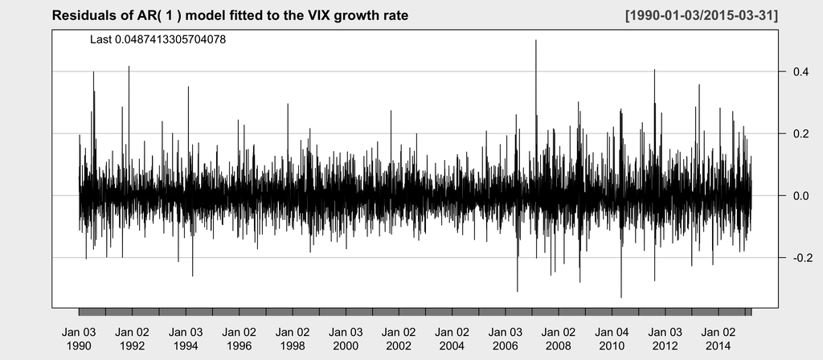

```r
res = resid(ARfit)
chartSeries(xts(res, index(z)),
            name = paste("Residuals of AR(", p, ") model fitted to the VIX growth rate"),
            theme=chartTheme("white", up.col='black'))
```

The sample ACF shows that although the autocorrelation at lag 1 is removed, there is still autocorrelation at higher lags. The Ljung-Box test for 5 and 10 lags are also highly significant.

```
	Box-Ljung test

data:  res
X-squared = 73.169, df = 4, p-value = 4.885e-15
```

```
	Box-Ljung test

data:  res
X-squared = 112.83, df = 9, p-value < 2.2e-16
```

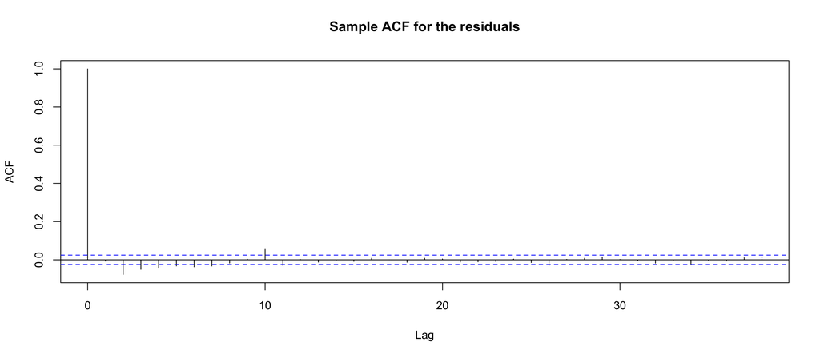

```r
acf(res, main="Sample ACF for the residuals")
Box.test(res, lag = 5, type = "Ljung-Box", fitdf = p)
Box.test(res, lag = 10, type = "Ljung-Box", fitdf = p)
```

We can stop the diagnostic at this point, since the model is not adequate. In other words, the model is not a good fit, as there is still significant auto-correlation in the residuals.

# 3

**(7 points)**

## (a)

**(2 points)** Is the AR(4) model

\begin{align*} r_t = 20 &-\frac{1}{90}\,r_{t-1} +\frac{1}{30}\,r_{t-2} +\frac{19}{90}\,r_{t-3} -\frac{3}{10}\,r_{t-4} + \eps_t, \end{align*}

weakly stationary? Justify your answer.

**Solution:** The characteristic equation of the AR(4) model is

\begin{align*} 1 + \frac{1}{90}\,x - \frac{1}{30}\,x^2 - \frac{19}{90}\,x^3 + \frac{3}{10}\,x^4=0 \end{align*}

The following code calculate the modulus of the roots.

```r
Mod(polyroot(c(1, 1/90, -1/30, -19/90, 3/10)))
```

1. 1.4815139717886

2. 1.23234872779929

3. 1.23234872779929

4. 1.4815139717886

Therefore, all the roots are outside the unit circle and the AR(4) process is stationary.

## (b)

**(1 point)** Assume that the AR(p) model $r_t = \phi_0 + \sum_{h=1}^p\,\phi_h r_{t-h} + \eps_t$ is weakly stationary. Find $\Eb(r_t)$ for all $t$.

**Solution:** Taking expectation from the AR(p) equation yields $\Eb(r_t) = \phi_0 + \sum_{h=1}^p\phi_h \Eb(r_{t-h})$. Since $\{r_t\}$ is stationary, we should have $\Eb(r_t)=\Eb(r_0)$, for all $t$. Therefore,

\begin{align*} \Eb(r_0) = \phi_0 + \sum_{h=1}^p\phi_h \Eb(r_0) \quad\Longrightarrow\quad \Eb(r_t) = \Eb(r_0) = \frac{\phi_0}{1-\sum_{h=1}^p\phi_h}. \end{align*}

## (c)

**(4 points)** Consider the AR(2) model $r_t = \phi_0 + \phi_1 r_{t-1} + \phi_2 r_{t-2} + \eps_t$ where $\{\eps_t\}$ is weak WN$(0,\sig_\eps^2)$. Assume that $\{r_t\}$ is weakly stationary. Calculate $\Var(r_t)$ and $\Cov(r_t,r_{t-1})$ for all $t$.

**Solution:**

Since the process is stationary, the second moments are time invariant (independent of $t$). Let $\gam(h)=\Cov(r_t,r_{t-h})$ be the autocovariance function. By the AR(2) equation, we have

\begin{align*} \gam(0) = \Var(r_t) &= \Var\(\phi_0 + \phi_1 r_{t-1} + \phi_2 r_{t-2} + \eps_t\)\\ &= \phi_1^2 \Var(r_{t-1}) + \phi_2^2 \Var(r_{t-2}) + \Var(\eps_t) + 2 \phi_1\, \phi_2\, \Cov(r_{t-1}, r_{t-2})\\ &\quad + 2 \phi_1\, \Cov(r_{t-1}, \eps_t) + 2 \phi_2\, \Cov(r_{t-2}, \eps_t). \end{align*}

Note that $\Var(r_{t-1})=\Var(r_{t-2})=\gam(0)$, $\Cov(r_{t-1}, r_{t-2}) = \gam(1)$, and $\Var(\eps_t)=\sig_\eps^2$. Furthermore, $\Cov(r_{t-1}, \eps_t)=\Cov(r_{t-2}, \eps_t) = 0$, since $r_{t-1}$ and $r_{t-2}$ only depend on $\eps_1,\dots,\eps_{t-1}$, which are uncorrelated with $\eps_t$. Thus, we obtain

\begin{align*} \gam(0) = (\phi_1^2 + \phi_2^2)\,\gam(0) + \sig_\eps^2 + 2 \phi_1\, \phi_2\, \gam(1) \quad\Longrightarrow\quad (1-\phi_1^2 - \phi_2^2)\,\gam(0) - 2 \phi_1\, \phi_2\, \gam(1) = \sig_\eps^2. \end{align*}

Similarly, by calculating $\gam(1) = \Cov(r_t, r_{t-1})$, we obtain

\begin{align*} \gam(1) = \Cov(r_t, r_{t-1}) &= \Cov\(\phi_0 + \phi_1 r_{t-1} + \phi_2 r_{t-2} + \eps_t, r_{t-1}\)\\ &= \phi_1 \Var(r_{t-1}) + \phi_2\,\Cov(r_{t-2}, r_{t-1}) + \Cov(\eps_t, r_{t-1})\\ &= \phi_1 \gam(0) + \phi_2\,\gam(1) + 0, \end{align*}

which, in turn, yields

\begin{align*} \phi_1 \gam(0) + (\phi_2-1)\,\gam(1) = 0. \end{align*}

Thus, $\gam(0)$ and $\gam(1)$ must satisfy the following system of equations,

\begin{align*} \begin{cases} (1-\phi_1^2 - \phi_2^2)\,\gam(0) - 2 \phi_1\, \phi_2\, \gam(1) = \sig_\eps^2\\ \phi_1 \gam(0) + (\phi_2-1)\,\gam(1) = 0. \end{cases} \end{align*}

Solving this system of equation for $\gam(0)$ and $\gam(1)$ yields

\begin{align*} \Var(r_t) = \gam(0) = \frac{\sig_\eps^2(\phi_2-1)}{(\phi_2-1)(1-\phi_1^2-\phi_2^2)+2\phi_1^2\phi_2}, \end{align*}

and

# 4.

**(15 points)** Consider the monthly crude oil prices from January 1987 to January 2018. Let $\{P_t\}$ be the monthly oil prices, and $r_t = \Delta P_t$ be the monthly price changes. The data can be obtained from FRED via `quantmod`. Alternatively, you may use the following code to obtain the data from the text file ``HW5-Q1.txt'' that is posted with this homework.

```r
library(xts)
dat=read.table("HW4-Q4.txt", header=TRUE, sep = ",")
P=xts(dat[,2], order.by=as.Date(dat[, 1]));names(P) = c("Oil")
r = diff(P)[-1]
```

## (a)

**(3 points)** Is $\{P_t\}$ a weak white noise? How about $\{r_t\}$? Run relevant tests, state their hypotheses and draw conclusions.

**Solution:** Let us take a look at the $\{P_t\}$.

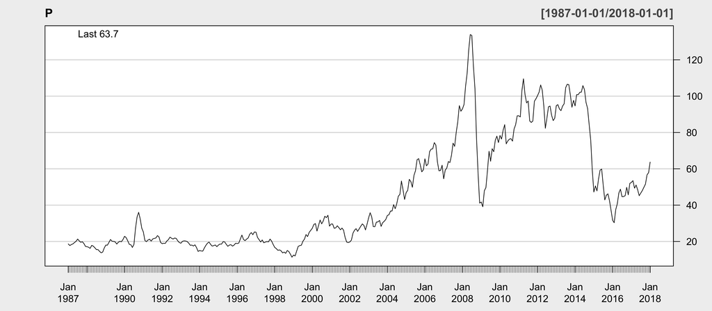

```r
library("quantmod")
chartSeries(P, theme=chartTheme("white", up.col='black'))
```

Clearly, the time series is not stationary. We can confirm this by the following unit root tests, which indicate non-stationarity (as expected from the plot). Since $\{P_t\}$ is not stationary, it cannot be a weak WN.

**Remark:** Note that before you plotting a sample ACF, you should establish that the process is stationary.

```r
library(tseries)
adf.test(P)
pp.test(P)
```

```
	Augmented Dickey-Fuller Test

data:  P
Dickey-Fuller = -2.4331, Lag order = 7, p-value = 0.3942
alternative hypothesis: stationary
```

```
	Phillips-Perron Unit Root Test

data:  P
Dickey-Fuller Z(alpha) = -16.785, Truncation lag parameter = 5, p-value
= 0.1707
alternative hypothesis: stationary
```

```r
kpss.test(P)
```

```
	KPSS Test for Level Stationarity

data:  P
KPSS Level = 4.2878, Truncation lag parameter = 5, p-value = 0.01
```

Next, let us plot $\{r_t\}$.

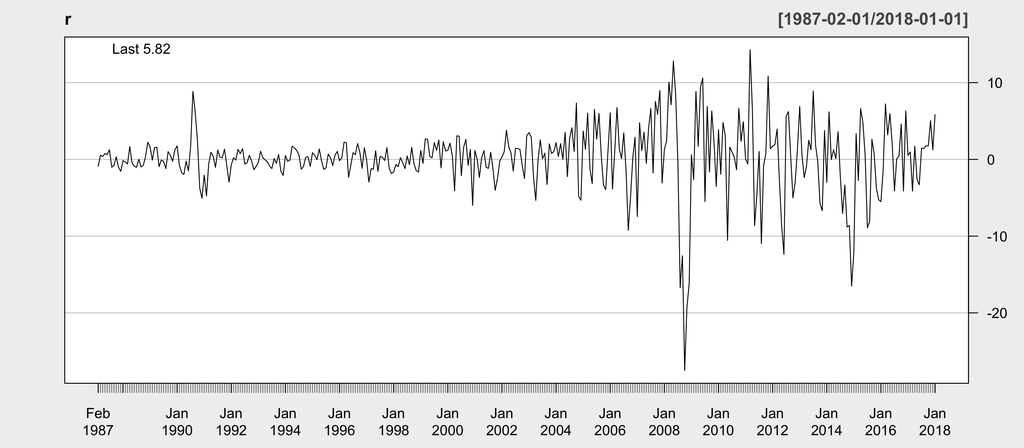

```r
chartSeries(r, theme=chartTheme("white", up.col='black'))
```

The mean seems to be time invariant, however, the variance may be time varying. Let us check if the time series is stationary or not, by applying unit-root tests.

As the following R code and output indicate, the ADF and PP reject the null hypothesis of non-stationarity, while the KPSS test accept the null hypothesis of stationarity. So, the process is stationary.

```r
adf.test(r)
pp.test(r)
```

```
	Augmented Dickey-Fuller Test

data:  r
Dickey-Fuller = -7.6895, Lag order = 7, p-value = 0.01
alternative hypothesis: stationary
```

```
	Phillips-Perron Unit Root Test

data:  r
Dickey-Fuller Z(alpha) = -227.35, Truncation lag parameter = 5, p-value
= 0.01
alternative hypothesis: stationary
```

```r
kpss.test(r)
```

```
	KPSS Test for Level Stationarity

data:  r
KPSS Level = 0.037465, Truncation lag parameter = 5, p-value = 0.1
```

Next, to check if the time series is weak WN, we check for autocorrelation in the time series by looking at the sample ACF plot and Ljung-Box test. The sample ACF plot shows significant autocorrelation at lags 1, 2, 5, 6, and 7. The Ljung-Box test rejects the null hypothesis that all the auto correlation at the first 20 lags are zero. So, $\{r_t\}$ is not weak WN.

```
	Box-Ljung test

data:  r
X-squared = 118.91, df = 20, p-value = 4.441e-16
```

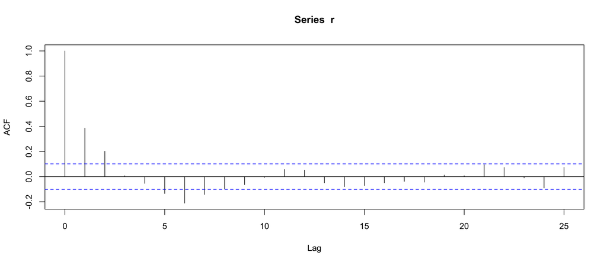

```r
acf(r)
Box.test(r, lag = 20, type = "Ljung-Box")
```

## (b)

**(5 point)** Fit an AR model for $\{r_t\}$ and state the fitted model. To choose the AR order, use the sample PACF plot. Is your model a good specification of the data? Support your answer with appropriate plots and tests.

**Solution:** We already established in part (a) that $\{r_t\}$ is stationary and that it is not a weak WN. To decide on the AR order, we plot its sample PACF.

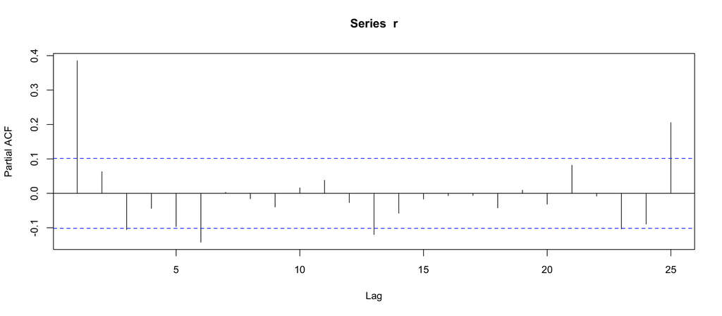

```r
pacf(r)
```

The sample PACF drops to zero after 1 lag, while there seems to be significant partial autocorrelation at lag 6 and 24. Based on this, we can use an AR(1) model. Using an AR(6) or AR(24) is not wrong (although, it may lead to an over-fitted model).

```r
ar=arima(r,order = c(1,0,0))
print(ar)
```

```
Call:
arima(x = r, order = c(1, 0, 0))

Coefficients:
         ar1  intercept
      0.3861     0.1289
s.e.  0.0478     0.3359

sigma^2 estimated as 15.87:  log likelihood = -1042.1,  aic = 2090.2
```

The fitted AR(1) model is

\begin{align*} r_t = 0.1289 + 0.3861 (r_{t-1} - 0.1289) + \eps_t;\quad \sigh_\eps^2= 15.87. \end{align*}

Next, we check if the model is adequate, using the `tsdiag()` function. The time series plot of the residuals look stationary. The sample ACF of the residuals shows significant autocorrelation at lag 6 and 24. The Ljung-Box test with 20 lags doesn't indicate autocorrelation. It is acceptable to conclude that the model is adequate based on the Ljung-Box test with 20 lags. It is also a correct answer to say that the model is inadequate, since there is autocorrelation left at lag 6 and 24.

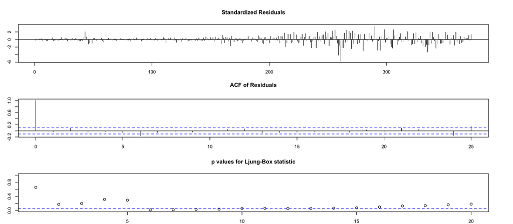

```r
par(mar=c(2,3,4,4))
tsdiag(ar, gof.lag = 20)
```

I we decide to ignore autocorrelation at lag 6 and 24 and conclude that the model is adequate, then, we should check for constant volatility and normality. Let us use the functions `tsdiag_vol` and `tsdiag_norm` from lecture 8.

```r
tsdiag_vol = function(model, lag, fitdf){
    par(mfrow=c(1,2));par(mar=c(3,3,3,3))
    plot(resid(model)**2, type="l", col=1, main = expression(residual^2))
    smoother = loess((resid(model)**2) ~ seq(1,length(resid(model))), span=0.1)
    lines(seq(1,length(resid(model))),fitted(smoother),col=2)
    acf((resid(model)**2), main=expression("sample ACF of "~ residual^2))
    Box.test(resid(model)**2, lag = lag, type = "Ljung-Box", fitdf = fitdf)
}

tsdiag_norm = function(model){
    qqnorm(resid(model), datax = TRUE,
       xlab = "normal quantile",
       ylab = "sample quantile of residuals",
       main = "normal probability plot for residuals")
    qqline(resid(model), datax=TRUE, col = 2)
    shapiro.test(resid(model))
}
```

the sample ACF plot of squared residuals and the corresponding Ljung-Box test indicates non-constant conditional variance.

```
	Box-Ljung test

data:  resid(model)^2
X-squared = 218.3, df = 11, p-value < 2.2e-16
```

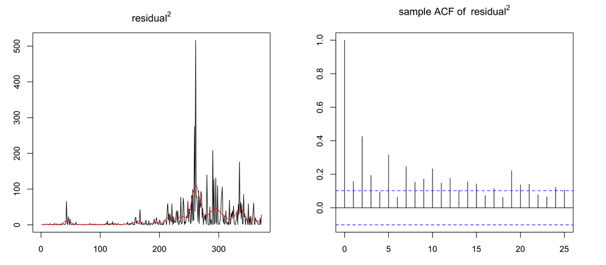

```r
tsdiag_vol(ar, lag=12, fitdf=1)
```

The normal probability plot of the residuals indicates non-normality due to heavy tails.

```
	Shapiro-Wilk normality test

data:  resid(model)
W = 0.93123, p-value = 4.552e-12
```

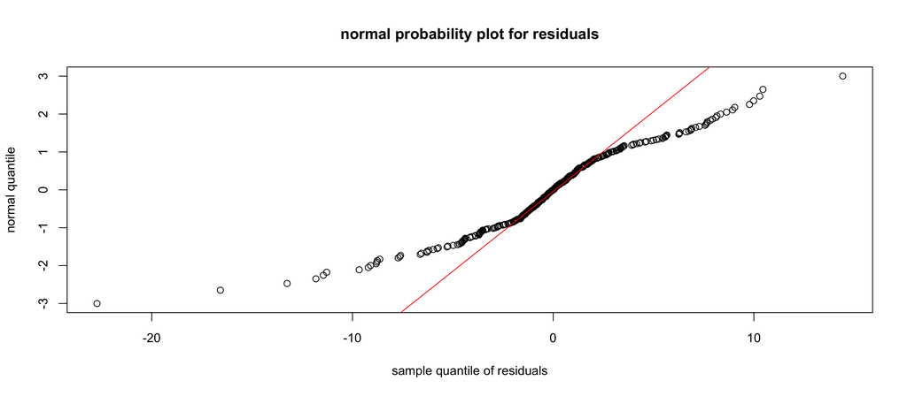

```r
tsdiag_norm(ar)
```

In summary, the AR(1) model significantly reduces autocorrelation in $\{r_t\}$. However, the assumptions of normality and constant conditional variance fail and need to be remedied.

## (c)

**(5 points)** Fit an MA model to $\{r_t\}$. State the fitted model. Use the sample ACF plot to decide on MA order. Is your MA model adequate?

**Solution:**

The sample ACF of $\{r_t\}$ drops to zero after 2 lags, so, we may choose a MA(2) model. However, there are significant autocorrelation at lags 5, 6 and 7. So, choosing an MA(7) model is also justified.

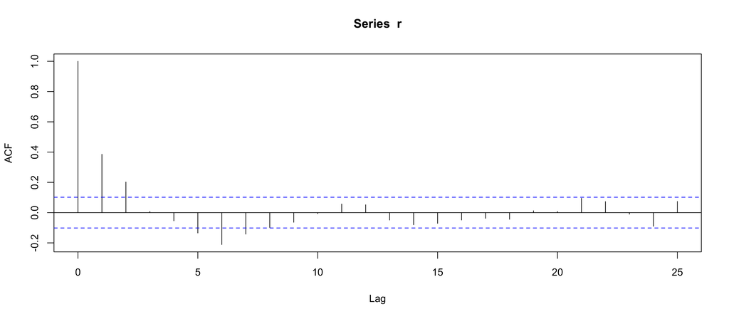

```r
acf(r)
```

Based on the R output below, the fitted MA(2) model is:

\begin{align} r_t = 0.1262 + \eps_t + 0.3657\, \eps_{t-1} + 0.2206\,\eps_{t-2};\quad \sigh_\eps^2= 15.68. \end{align}

```r
ma=arima(r,order = c(0,0,2))
ma
```

```
Call:
arima(x = r, order = c(0, 0, 2))

Coefficients:
         ma1     ma2  intercept
      0.3657  0.2206     0.1262
s.e.  0.0510  0.0493     0.3252

sigma^2 estimated as 15.68:  log likelihood = -1039.88,  aic = 2087.77
```

The residual diagnostic below indicates that the residuals are weak WN. So, the model is adequate.

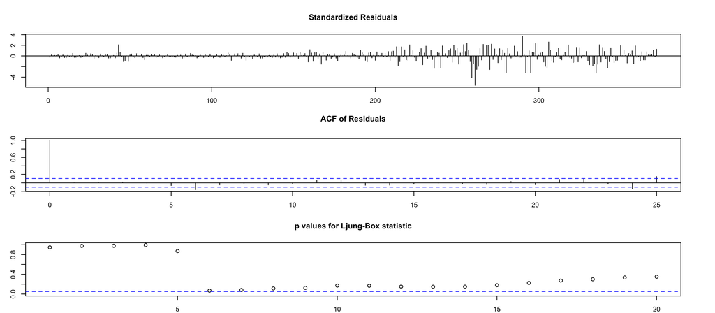

```r
par(mar=c(2,3,4,4))
tsdiag(ma, gof.lag = 20)
```

Further diagnostic indicate that the volatility is not constant and the residuals are not normal.

```
	Box-Ljung test

data:  resid(model)^2
X-squared = 218.3, df = 10, p-value < 2.2e-16
```

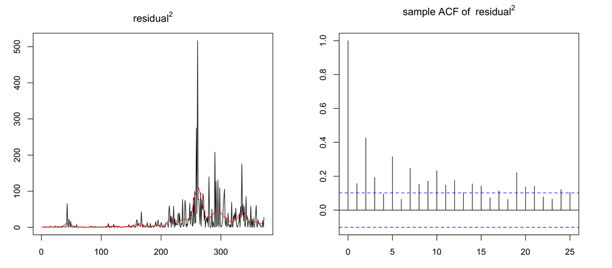

```r
tsdiag_vol(ar, lag=12, fitdf=2)
```

```
	Shapiro-Wilk normality test

data:  resid(model)
W = 0.93123, p-value = 4.552e-12
```

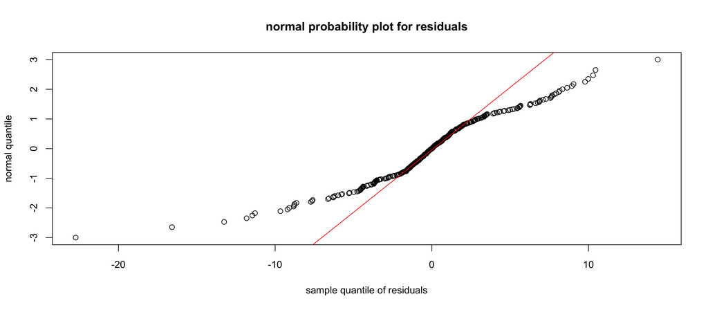

```r
tsdiag_norm(ar)
```

## (d)

**(2 points)** Use information criteria AIC and BIC to choose an ARIMA(p,d,q) for $\{P_t\}$. Comment on adequacy of your model.

**Solution:**

For both AIC and BIC, `auto.arima()` choose an ARMIMA(1,1,0) with zero mean for $\{P_t\}$. This is the model fitted in part (b) with the additional assumption that the intercept is zero. The fitted model is (compare it with part (b)):

\begin{align*} P_t - P_{t-1} = 0.3866 (P_{t-1} - P_{t-2}) + \eps_t;\quad \sigh_\eps^2= 15.92. \end{align*}

```r
library(forecast)
auto.arima(P, max.p = 20, max.q=20, max.d = 2, ic="bic")
arma=auto.arima(P, max.p = 20, max.q=20, max.d = 2, ic="aic")
arma
```

```
Series: P
ARIMA(1,1,0)

Coefficients:
         ar1
      0.3866
s.e.  0.0478

sigma^2 estimated as 15.92:  log likelihood=-1042.17
AIC=2088.34   AICc=2088.38   BIC=2096.18
```

```
Series: P
ARIMA(1,1,0)

Coefficients:
         ar1
      0.3866
s.e.  0.0478

sigma^2 estimated as 15.92:  log likelihood=-1042.17
AIC=2088.34   AICc=2088.38   BIC=2096.18
```

The result of the residual diagnostic is similar to that of part (b).

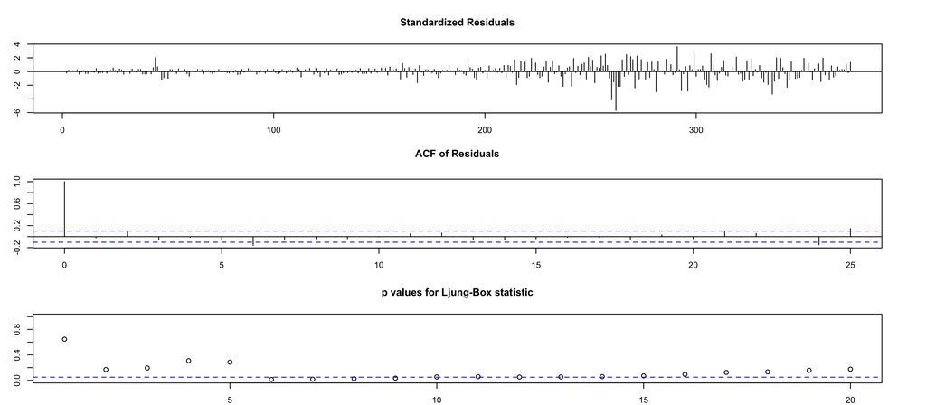

```r
par(mar=c(2,3,4,4))
tsdiag(arma, gof.lag = 20)
```

```
	Box-Ljung test

data:  resid(model)^2
X-squared = 222.65, df = 10, p-value < 2.2e-16
```

```
	Shapiro-Wilk normality test

data:  resid(model)
W = 0.93078, p-value = 3.899e-12
```

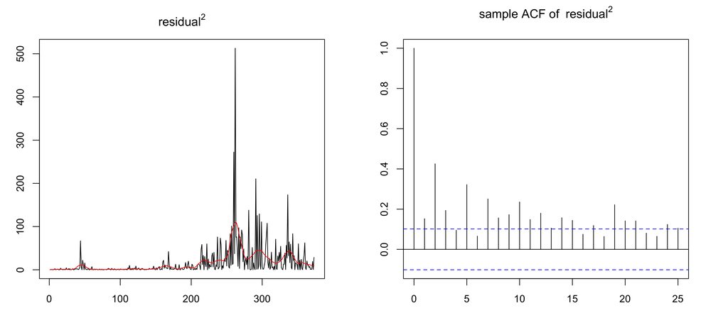

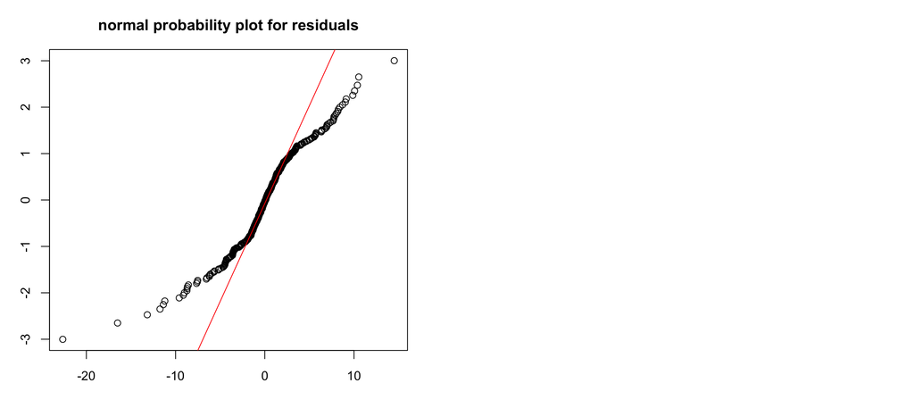

```r
tsdiag_vol(arma, lag=12, fitdf=2)
tsdiag_norm(arma)
```

# 5

**(10 points)** Use the following code to obtain global temperatures from the text file "HW5-Q2.txt" that accompanies this homework.

```r
dat = read.table("HW4-Q5.txt",header=T)
dd = dat[,2:13]
x  = c(t(dd))
```

The data includes temperature measurements from January 1880 to December 2015 for the Northern Hemisphere, in 0.01C. Let $\{x_t\}$ be the global temperatures.

## (a)

**(3 points)** Is the temperature series a stationary process? Conduct three relevant test, state their hypotheses and conclusions.

**Solution:**

The result is inconclusive. ADF and PP tests reject their null hypothesis that the series has unit root, while the KPSS test reject the null hypothesis that the series is stationary.

```r
adf.test(x)
pp.test(x)
kpss.test(x)
```

```
	Augmented Dickey-Fuller Test

data:  x
Dickey-Fuller = -4.2887, Lag order = 11, p-value = 0.01
alternative hypothesis: stationary
```

```
	Phillips-Perron Unit Root Test

data:  x
Dickey-Fuller Z(alpha) = -663, Truncation lag parameter = 8, p-value =
0.01
alternative hypothesis: stationary
```

```
	KPSS Test for Level Stationarity

data:  x
KPSS Level = 12.506, Truncation lag parameter = 8, p-value = 0.01
```

## (b)

**(4 points)** Let $z_t = x_t - x_{t-1}$ be the monthly change in the global temperature. Is the average monthly changes in the temperature zero? Is the process $\{z_t\}$ stationary? State appropriate statistical tests, and draw your conclusion.

**Solution:**

The 95\% confidence interval of the mean includes zero. See entries `LCL` and `UCL` below, the confidence interval for the mean is $[LCL,UCL]$. Thus, the null hypothesis of $H_0:$ mean=0 is accepted.

```r
library(fBasics)
z = diff(x)
basicStats(z)
```

A data.frame: 16 × 1

|  | z <dbl> |
| --- | --- |
| nobs | 1631.000000 |
| NAs | 0.000000 |
| Minimum | -103.000000 |
| Maximum | 101.000000 |
| 1. Quartile | -11.000000 |
| 3. Quartile | 12.000000 |
| Mean | 0.121398 |
| Median | 1.000000 |
| Sum | 198.000000 |
| SE Mean | 0.534513 |
| LCL Mean | -0.927007 |
| UCL Mean | 1.169803 |
| Variance | 465.984027 |
| Stdev | 21.586663 |
| Skewness | -0.147598 |
| Kurtosis | 1.924951 |

The three unit-root test indicate that $\{z_t\}$ is stationary.

```r
adf.test(z)
pp.test(z)
kpss.test(z)
```

```
	Augmented Dickey-Fuller Test

data:  z
Dickey-Fuller = -17.703, Lag order = 11, p-value = 0.01
alternative hypothesis: stationary
```

```
	Phillips-Perron Unit Root Test

data:  z
Dickey-Fuller Z(alpha) = -1769.8, Truncation lag parameter = 8, p-value
= 0.01
alternative hypothesis: stationary
```

```
	KPSS Test for Level Stationarity

data:  z
KPSS Level = 0.021166, Truncation lag parameter = 8, p-value = 0.1
```

## (c)

**(3 points)** Fit an ARIMA model to $\{x_t\}$. State the fitted model and conduct a full model diagnostic.

**Solution:**

`auto.arima()` suggests the ARIMA(1,1,2) model for $\{x_t\}$:

\begin{align} z_t = 0.7032\,z_{t-1} + \eps_t - 1.2915\,\eps_{t-1} + 0.3194\,\eps_{t-2};\quad \sigh_\eps^2=343.1. \end{align}

Note that we used $z_t$ since the integration order is 1.

```r
arma=auto.arima(x, max.p = 20, max.q=20, max.d = 2, ic="bic")
print(arma)
```

```
Series: x
ARIMA(1,1,2)

Coefficients:
         ar1      ma1     ma2
      0.7032  -1.2915  0.3194
s.e.  0.0511   0.0625  0.0559

sigma^2 estimated as 343.1:  log likelihood=-7074.39
AIC=14156.78   AICc=14156.8   BIC=14178.37
```

The model is not adequate, however. The following residual analysis indicates that the residuals are not weak WN.

**Remark:** As we will confirm in the next homework, the inadequacy of the model is due to seasonality.

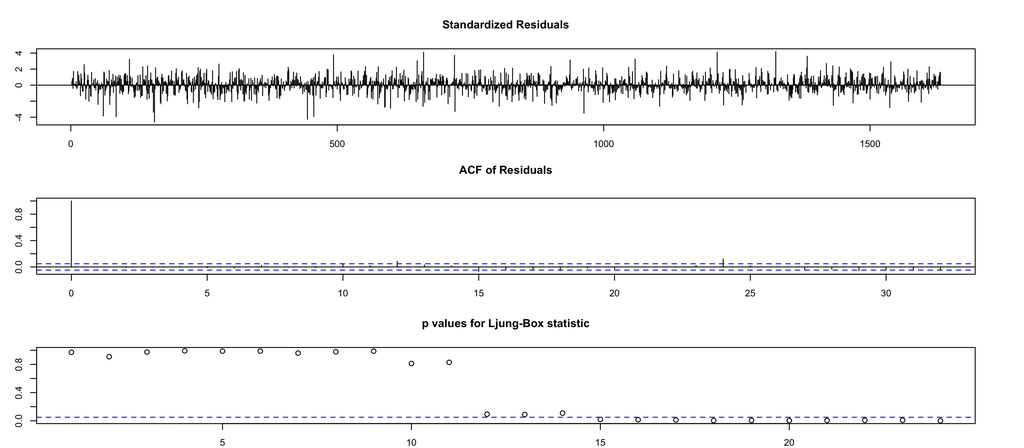

```r
par(mar=c(2,3,4,4))
tsdiag(arma, gof=24)
```